# Lab3

Jakub Domasik

22 10 2019

# 1. Get the Data

```r
library(dplyr)
library(lubridate)
library(ggplot2)
require(dplyr)
require(ggplot2)
library(readxl)
library(tidyverse)
library(rio)
Spotify <- import("edited_spotify.xlsx")
MyData = {Spotify %>%
    group_by(Artist,AlbumName,AlbumReleaseDate) %>%
    summarize(AlbumValence = mean(TrackValence),
              AlbumSpeechiness = mean(TrackSpeechiness),
              AlbumLiveness = mean(TrackLiveness) )}
MyData$AlbumReleaseDate = parse_date_time(MyData$AlbumReleaseDate,orders=c("y","ym","ymd"))
```

# Graph no 1

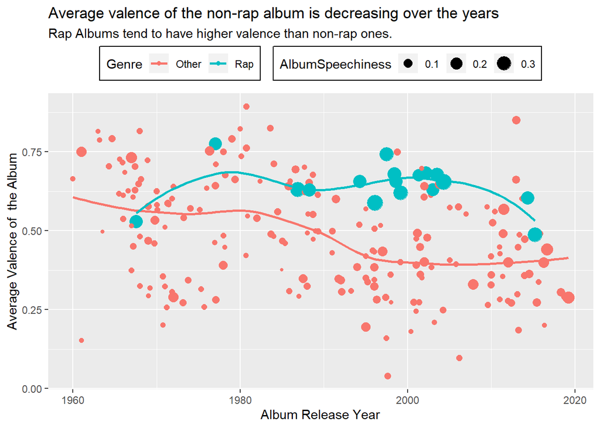

```r
MyData$Genre <- "Other"
MyData$Genre[MyData$AlbumSpeechiness>0.2] <- "Rap"
myplot1 <- { MyData %>% ggplot(aes(x = AlbumReleaseDate,  y = AlbumValence, fill = Genre, color = Genre))} + geom_point(aes(size=AlbumSpeechiness)) +
geom_smooth(method = loess, se=FALSE) + xlab( "Album Release Year") + ylab ( "Average Valence of  the Album") + theme(legend.position= "top", legend.background = element_rect(fill="white", size=0.5, linetype = "solid", colour="black"))  +
  labs(title = "Average valence of the non-rap album is decreasing over the years", subtitle = "Rap Albums tend to have higher valence than non-rap ones.")
myplot1
```

```r
svg(file = "Kuba-plot.svg", width = 8, height = 5)
print(myplot1)
dev.off()
```

Spotify’s database describes *Valance* as a measure from 0.0 to 1.0 describing the musical positiveness conveyed by a track. Tracks with high *valence* sound more positive (e.g. happy, cheerful, euphoric), while tracks with low *Valence* sound more negative (e.g. sad, depressed, angry). This graph plots average *Valence* of each album in a dataset, against the release date of the album. The variable *Genre* was created to indicate which album contains most likely rap music and which do not. From the scatterplot, we indicate that generally, the *Valance* of an album tends to be negatively correlated with the release date of the album. This means, that newer albums are typically sadder than older ones. The graph also shows a difference in valance between rap and non-rap albums. Rap albums are generally more valent than non-rap ones. There are only two albums classified as “rap” which were released before 1980 and the majority of“rap” albums in our dataset was published from 1990 to 2005. These albums are relatively high *Valence* which is usually higher than 0.5.

We conclude that generally newer albums are more pessimistic than older ones and that *rap* albums tend to be more positive on average. It is hard to find any other sensible patterns in this graph as our dataset is rather small and *rap* albums are hugely underrepresented in the dataset.

# Grapgh no 2

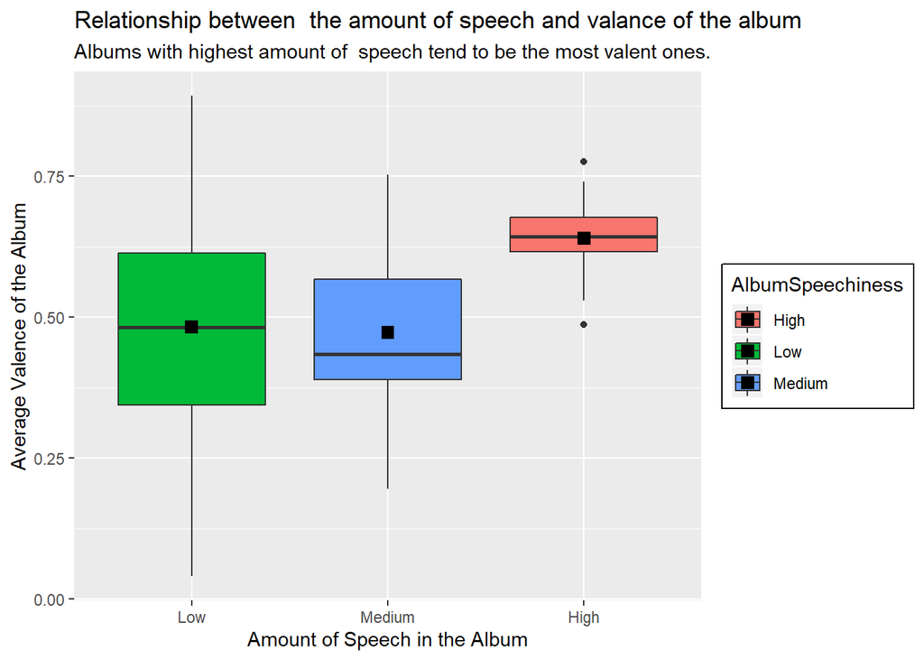

```r
MyData$AlbumSpeechiness[MyData$AlbumSpeechiness>0.21] <- "High"
MyData$AlbumSpeechiness[MyData$AlbumSpeechiness<=0.1] <- "Low"
MyData$AlbumSpeechiness[MyData$AlbumSpeechiness>0.1 & MyData$AlbumSpeechiness<=0.2] <- "Medium"

library(ggplot2)
myplot2 <-ggplot(data=MyData, aes(x = AlbumSpeechiness, y=AlbumValence, fill = AlbumSpeechiness)) + geom_boxplot() +
  theme(legend.position= "right", legend.background = element_rect(fill="white", size=0.5, linetype = "solid", colour="black")) +
  scale_x_discrete(limits=c("Low", "Medium", "High")) +
  stat_summary(fun.y = mean, geom="point", shape=15, size = 3) +
  ylab("Average Valence of the Album") + xlab("Amount of Speech in the Album") +
  labs(title = "Relationship between  the amount of speech and valance of the album", subtitle = "Albums with highest amount of  speech tend to be the most valent ones.")
myplot2
```

The variable *“AlbumSpeechiness”* was transformed into a discrete one with one of three values: *Low*, *Medium* and *High*. Those values indicate how much speech each album contains on average. The boxplot was created to plot *AlbumSpeechiness* against the *AlbumValence*. The graph indicates that albums with *low* to *medium* *Speechiness* tend to have similar valance although the first box which contains albums with the low amount of speech have much greater variance and range. Furthermore, albums with *high* spechiness are on average more valent than others with median and mean around 0.63 while others have then below 0.5. We can say that albums with *low* amount of speech are the most versatile in terms of *Valence*. However, out of 10 most valent albums, 9 have *low* valence and only one has *high* *Valence*. This may be the result of the distribution of *AlbumSpeechiness* in the dataset where the majority of the albums have *low* *speechiness* while only a few have *high* *Valance*.

We conclude that albums with no to little speech are the most versatile in terms of _valence. We also confirm our finding from the previous graph that *rap* albums are more optimistic on average but the majority of the most positive songs contain no to little speech.